# Sampling and the Central Limit Theorem

Steve Elston

02/03/2022

# Review of Probability Distributions

- Common discrete and continuous distributions
- **Probability mass function (PMF)** of discrete distributions are summed to find probability
- **Probability density function (PDF)** of continuous distributions is integrated to find probability
- **Inverse PDF/PMF** to find quantile of a given probability
- **Simulation** uses realizations (draws) from independent and conditional distributions

# Probability Distributions

**Probability distributions** are models for uncertainty of **random variables**

- A random variable is any **mapping**, $X$, from from some outcome of a random event, $\omega$, to a real number, $\mathbb{R}$:

$$X(\omega) \rightarrow \mathbb{R}$$

- **Example:** The mapping can be a count
- **Example:** A function which transforms $\omega$ to a real number, $\mathbb{R}$
- This concept appears abstract at first glance, but is fundamental to the theory of probability
- We will see many examples in this course

# Common discrete distributions

**Discrete distributions** are characterized by their **probability mass functions (PMF)**

- **Discrete uniform:** for equally likely outcomes, such as the result of rolling a dice
- **Bernoulli:** for a single binary outcome, such as a single coin flip
- **Binomial:** the **number of “successes”** in $n$ independent Bernoulli trials with fixed probability $p$ of success, where “success” is defined by you, such as the number of heads in $n = 20$ coin flips
- **Poisson:** used for modeling counts, such as the number of customers visiting a store on any day
- **Geometric:** the number of Bernoulli trials (with $p$ fixed) before we see a successful outcome, such as the number of coin flips before we see a tails

# Common continuous distributions

**Continuous distributions** are defined by a **probability density function (PDF)**

- **Uniform:** when ranges of data with equal length are equally likely, such as how gas molecules spread in a room
- **Normal:** data that is symmetric and bell-shaped, such as people’s height, or measurement error if instrument is not **biased**
- **Exponential:** heavily right-skewed data, such as lifetime of a light bulb
- **Log normal:** skewed data, such as “dwell time” on an online article
- **Power law:** for data that appear to follow the **“80-20 rule”**
- **Gamma and chi-square** is used for a sum of the squares of $k$ independent standard normal random variables, and is used by many **statistical tests**

# today’s agenda

- sample vs population
- sources of uncertainty
- sampling methods
- the law of large numbers
- the Central Limit Theorem
- Bootstrap estimation - Time permitting

# Introduciton to Sampling

Sampling is a fundamental process in the collection and analysis of data

- Sampling is important because we almost never have data on a whole population
- If we had access to the **whole population** we could measure anything we wanted, with only **epistemic uncertainty**
- Sampling must be randomized to preclude biases
- Key points to keep in mind:
  - Understanding sampling is essential to ensure data is representative of the entire population
  - Use inferences on the sample to say something about the population
  - The sample must be randomly drawn from the population
- Sampling from distribution is the building block of simulation
- We wil take up the topic of resampling later

# sample vs population

- a **population** is a group of things / people we are targeting
- there is one population and it is usually very large, even infinite
  - all our current and future customers’ age
  - all normally distributed numbers with mean $\mu$ and standard deviation $\sigma$
- we call $\mu$ and $\sigma$ **population parameters** and they are **fixed** (unless you’re a Bayesian, but we return to this later)
- a **sample** is a smaller subset of the population (usually much smaller)
  - the age of the customers I have in the database *right now*
  - $n$ numbers drawn from $N(\mu, \sigma)$ (or any other distribution)
- we can compute **statistics** for our sample, such as the sample mean $\bar x$ and the sample standard deviation $s$, but statistics **vary** because samples vary

# Sampling Examples

| Use Case | Sample | Population |
| --- | --- | --- |
| A/B Testing | The users we show either web sites A or B | All possible users, past present and future |
| World Cup Soccer | 32 teams which qualify in one season | All national teams in past, present and future years |
| Average height of data science students | Students in a data science class | All students taking data science classes world wide |
| Tolerances of a manufactured part | Samples taken from production lines | All parts manufactured in the past, present and future |
| Numbers of a species in a habitat | Population counts from sampled habitats | All possible habitats in the past, present and future |

- In several cases it is not only impractical, but impossible to collect data from the entire population

# Importance of Random Sampling

All statistical methods rely on the use of **randomized unbiased samples**

- Failure to randomized samples violates many key assumptions of statistical models
- An understanding of proper use of sampling methods is essential to statistical inference
- Most commonly used machine learning algorithms assume that training data are **unbiased** and **independent identically distributed (iid)**
  - These conditions only met if training data sample is randomized
  - Otherwise, the training data will be biased and not represent the underlying process distribution

# Sampling Distributions

Sampling of a population is done from an unknown **population distribution**, $\mathcal{F}$

- Any statistic we compute for the generating process is based on a sample, $\hat{\mathcal{F}}$
- The statistic is an approximation, $s(\hat{\mathcal{F}})$ of a **population parameter**
  - For example, the mean of the population is $\mu$
  - But, sample estiamte is $\bar{x}$
- If we continue to take random samples from the population and compute estimates of a statistic, we generate a **sampling distribution**
  - Hypothetical concept of the sampling distribution is a foundation of **frequentist statistics**
  - Example, if we continue generating samples and computing the sample means, $\bar{x}_i$ for the ith sample
- **Frequentist statistics** built on the idea of randomly resampling the population distribution and recomputing a statistic
  - In the frequentist world, statistical inferences are performed on the sampling distribution
  - Sampling process must not bias the estimates of the statistic

# Sampling Distributions

Sampling of a population is done from an unknown **population distribution**, $\mathcal{F}$

- Any statistic we compute for the generating process is an approximation for the population, $s(\hat{\mathcal{F}})$

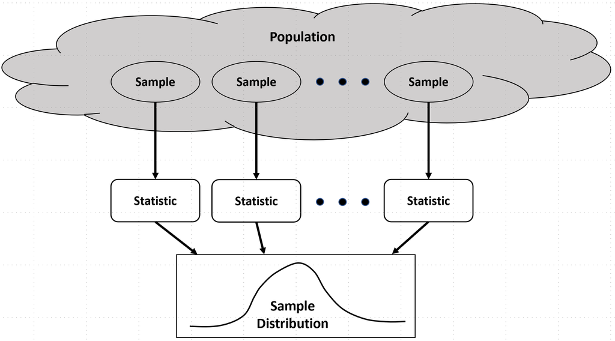

Sampling distribution of unknown population parameter

# Sampling and the Law of Large Numbers

The **law of large numbers** is a theorem that states that **statistics of independent random samples converge to the population values as more samples are used**

- Example, for a population distribution, $\mathcal{N}(\mu,\sigma)$, the sample mean is:

$$Let\ \bar{X} = \frac{1}{n}\sum_{i=1}^{n} X_i$$

Then by the law of Large Numbers:

$$\bar{X} \rightarrow E(X) = \mu\\
as\\
n \rightarrow \infty$$

- This result is reassuring, the larger the sample the more the statistic converges to the population parameter

# Sampling and the Law of Large Numbers

The law of large numbers is foundational to statistics

- We rely on the law of large numbers whenever we work with samples
- Assume that **larger samples are more representatives of the population we are sampling**
- Is foundation of sampling theory, plus modern computational methods; simulation, bootstrap resampling, and Monte Carlo methods
- If the real world did not follow this theorem, then much of statistics (to say nothing of science and technology as a whole) would have to be rethought

# Sampling and the Law of Large Numbers

The law of large numbers has a long history

- Jacob Bernoulli posthumously published the first proof for the Binomial distribution in 1713
- Law of large numbers is sometimes referred to as **Bernoulli’s theorem**
- A more general proof was published by Poisson in 1837.

# Sampling and the Law of Large Numbers

A simple example

- The mean of fair coin flips (0,1) = (T,H) converges to the expected value with more flips
- The mean converges to the expected value of 0.5 for $n = 5, 50, 500, 5000$

```
## 5  0.80
## 50  0.36
## 500  0.48
## 5000  0.49
```

# Sampling and the Law of Large Numbers

A simple example; mean of fair coin flips (0,1) = (T,H) converges to the expected value with more flips

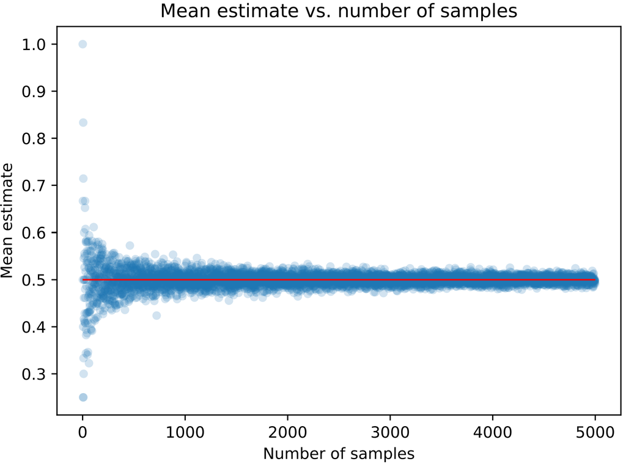

Convergance of mean estimates for fair coin

# the Central Limit Theorem (CLT)

- Law of large number is almost too obvious, but the CLT is more tricky!
- Law of large number applied to any statistic, but the CLT applies only to the **mean**
- Let $X$ be a random variable representing the population
  - $X$ is allowed to have **any distribution** (not limited to normal), and let $\mu$ be your **true population mean** and $\sigma$ the **true population standard deviation**
  - Given sample size $n$ thee sampling distribution of $\bar X$is

$$\bar X \sim N(\mu, \frac{\sigma}{\sqrt n})$$

# importance of CLT

CLT is a sort of guarantee

- Sampling distribution of mean estimates do not depend on the population the sample was drawn from
- **Standard deviation** $s$ of the sampling distribution of $\bar{x}$ converges as $1/\sqrt n$
- Only depends on the population’s mean and variance, and on the sample size
- CLT is the basis for hypothesis testing

# Example of CLT

Start with a mixture of Normal distributions

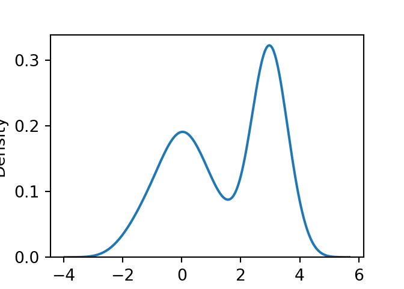

# Example CLT

Sample distribution of the mean of mixture of Normals is Normally distributed!

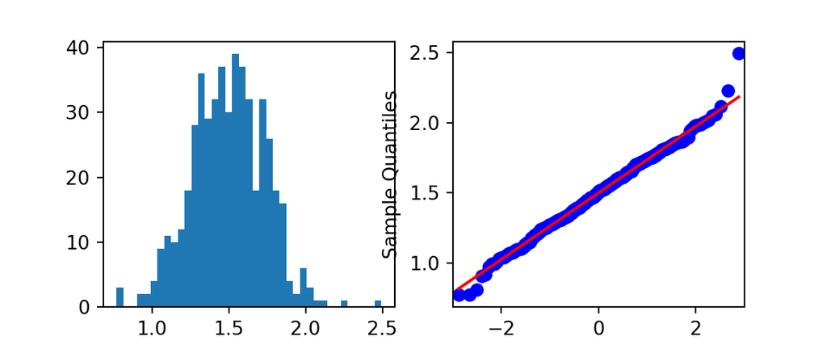

# Standard Error and Convergence for a Normal Distribution

As we sampled from a Normal distribution, the mean and standard deviation of the sample converged to the population mean

- What can we say about the expected error of the mean estimate as the number of samples increases?
  - This measure is known as the **standard error** of the sample mean
  - As corollary of the law of large numbers the standard error is defined:

$$se = \pm \frac{sd}{\sqrt{(n)}}$$

- Standard error decreases as the square root of $n$
  - Example, if you wish to halve the error, you will need to sample four times as many values.
- For the mean estimate, $\bar{x}$, define the uncertainty in terms of **confidence intervals**
  - For 95% confidence interval:

$$CI_{95} =\bar{x} \pm 1.96\ se$$

# Convergence and Standard Errors for a Normal Distribution

Mean estimates for realizations of standard Normal distribution with standard errors

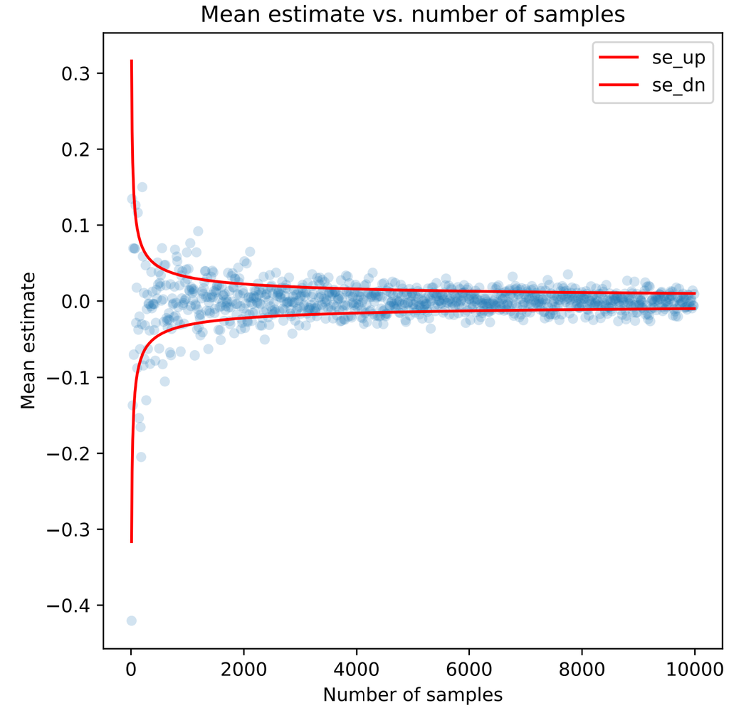

Convergance of mean estimates with standard errors

# Sampling Strategies

There are a great number of possible sampling methods.

- Some of the most commonly used methods
- **Bernoulli sampling**, a foundation of random sampling
- **Stratified sampling**, when groups with different characteristics must be sampled
- **Cluster sampling**, to reduce cost of sampling
- **Systematic sampling and convenience sampling**, a slippery slope

# Bernoulli Sampling

**Bernoulli sampling** is a widely used foundational random sampling strategy

- Bernoulli sampling has the following properties:
- A **single random sample** of the population is created
- A particular value in the population is selected based on the outcome of a Bernoulli trial with fixed probability of success, $p$
- Example, a company sells a product by weight
  - To ensure the quality of a packaging process so few packages are underweight
  - Impractical to empty and weight the contents of every package
  - Bernoulli randomly sampled packages from the production line and weigh contents
  - Statistical inferences are made from sample

# Bernoulli Sampling

An example with synthetic data. - Generate 2,000 random samples from the standard Normal distribution  
- The realizations are randomly divided into 4 groups with $p = [0.1,0.3,0.4,0.2]$  
- The probability of a sample being in a group is not uniform, and sums to 1.0.

- Head of the data frame is displayed:

```python
nr.seed(345)
population_size = 2000
data = pd.DataFrame({"var":nr.normal(size = population_size),
                     "group":nr.choice(range(4), size= population_size, p = [0.1,0.3,0.4,0.2])})
data.head(10)
```

```
##         var  group
## 0  1.469248      1
## 1 -1.150144      2
## 2  2.519226      3
## 3 -0.082478      3
## 4 -0.033601      1
## 5 -1.636656      2
## 6 -0.412092      2
## 7  1.784949      2
## 8  0.042383      1
## 9 -0.619732      3
```

# Bernoulli Sampling

The population of 2000 values was sampled from the standard Normal distribution

The mean of each group should be close to 0.0:  
1. The sample is divided between 4 groups  
2. Summary statistics are computed for each group

```
##        Count      Mean        SE  Upper_CI  Lower_CI
## group
## 0        200 -0.004609  0.070616  0.133799 -0.143016
## 1        619 -0.033427  0.040424  0.045804 -0.112658
## 2        812 -0.020730  0.035096  0.048058 -0.089518
## 3        369 -0.011268  0.049748  0.086237 -0.108774
```

# Sampling Grouped Data

Group data is quite common in application

A few examples include:

1. Pooling opinion by county and income group, where income groups and counties have significant differences in population
2. Testing a drug which may have different effectiveness by sex and ethnic group
3. Spectral characteristics of stars by type

# Stratified Sampling

What is a sampling strategy for grouped or stratified data?

- **Stratified sampling** strategies are used when data are organized in **strata**
- **Simple Idea:** independently sample an equal numbers of cases from each strata
- The simplest version of stratified sampling creates an **equal-size Bernoulli sample** from each strata
- In many cases, nested samples are required
  - For example, a top level sample can be grouped by zip code, a geographic strata
  - Within each zip code, people are then sampled by income bracket strata
  - Equal sized Bernoulli samples are collected at the lowest level

# Example

```
##        Count      Mean        SE  Upper_CI  Lower_CI
## group
## 0         20 -0.090846  0.228964  0.357923 -0.539615
## 1         20 -0.115536  0.265127  0.404114 -0.635185
## 2         20 -0.117146  0.211610  0.297611 -0.531902
## 3         20  0.093212  0.239734  0.563091 -0.376667
```

# Cluster Sampling

When sampling is expensive, a strategy is required to reduce the cost

- Examples of expensive to collect data:
  - Surveys of customers at a chain of stores
  - Door to door survey of homeowners
  - Sampling wildlife populations in a dispersed habitat

Population can be divided into randomly selected clusters:  
- Define the clusters for the population  
- Randomly select the required number of clusters  
- Sample from selected clusters  
- Optionally, stratify the sample within each cluster

# Cluster Sampling

As an example, select a few store locations and Bernoulli sample customers at these locations.

```
##        Count      Mean        SE  Upper_CI  Lower_CI
## group
## 0        105  0.084543  0.086166  0.253429 -0.084343
## 1        111 -0.162994  0.090840  0.015053 -0.341041
## 2         89 -0.031656  0.101022  0.166347 -0.229659
## 3         85 -0.228978  0.107572 -0.018137 -0.439819
## 4        107 -0.130628  0.094591  0.054770 -0.316026
## 5         84  0.094159  0.129610  0.348196 -0.159877
## 6         94  0.060410  0.105054  0.266315 -0.145495
## 7        111 -0.029124  0.093599  0.154330 -0.212579
## 8        113 -0.029280  0.085334  0.137975 -0.196534
## 9        101  0.096571  0.103060  0.298568 -0.105426
```

# Cluster Sampling

Randomly select 3 clusters

```
## cluster sampled are:
```

```
## 9
## 2
## 5
```

Display summary statistics

```
##        Count      Mean        SE  Upper_CI  Lower_CI
## group
## 2         89 -0.031656  0.101022  0.166347 -0.229659
## 5         84  0.094159  0.129610  0.348196 -0.159877
## 9        101  0.096571  0.103060  0.298568 -0.105426
```

# Systematic Sampling

**Convenience and systematic sampling** are a slippery slope toward biased inferences

- Systematic methods lack randomization
- Convenience sampling selects the cases that are easiest to obtain
  - Commonly cited example known as **database sampling**
  - Example, the first N rows resulting from a database query
  - Example, every k-th case of the population

# A Few More Thoughts on Sampling

There are many practical aspects of sampling.

- Random sampling is essential to the underlying assumptions of statistical inference
- Whenever you are planning to sample data, make sure you have a clear sampling plan
- Know the number of clusters, strata, samples in advance
- Don’t just stop sampling when your desired result is achieved: e.g. error measure!

# Introduction to Resampling and bootstrap

“There were others who had forced their way to the top from the lowest rung by the aid of their bootstraps.” James Joyce, ‘Ulysses’ 1922

Bootstrap and re-sampling methods are widely applicable statistical methods

- Resampling methods are products of the computer age
- Use computational resources unimaginable in the early 20th Century
- Repeatedly re-sampling the data relaxes some of the assumptions of classical statistical methods
- Re-sampling methods draw heavily on the law of large number and the central limit theorem

# Types of Resampling Methods

Commonly used re-sampling methods include:

- **Randomization or Permutation methods:** aka exact tests
  - Have a long history; e.g. Fisher’s exact test (1922)
  - Became practical for larger data sets in computer era
- **Cross validation:** re-sample into multiple folds without replacement
  - Leave n out method
  - Has origins in the 1950s
  - Widely used to evaluate machine learning (ML) models
- **Jackknife:** leave one out re-sampling
  - Leave one out method
  - Early general purpose resampling method
  - Has origins in the 1950s
- **Bootstrap:** re-sample with equivalent size and replacement - our focus here
  - Published by Prof Brad Efron in 1979

# General Characteristics of Resampling Methods

General characteristics of resampling methods include

- Allow computation of statistics from limited data samples for statistics with continuous derivatives
- Repeatedly compute statistics from multiple resamples of dataset
- The result converges to the sample distribution of the statistic being computed
- Make minimal distributional assumptions, when compared to classical frequentist statistics

# Pitfalls of Resampling Methods

Re-sampling methods are general and powerful but, there is no magic involved! There are pitfalls!

- If a sample is biased, the re-sampled statistic estimate based on that sample will be biased
  - Results can be no better than the sample you start with
  - Example; the bootstrap estimate of mean is the unbiased sample estimate, $\bar{x}$, not the population parameter, $\mu$
- The sample variance and Cis can be no better than the sample distribution allows
  - Be suspicious of overly optimistic confidence intervals
  - CIs can be optimistically biased
- Are computationally intensive, but often highly parallelizable

# Point Estimates vs. Distribution Estimates

The goal of frequentist statistics is to compute a point estimate and confidence interval

- Point estimate is the single most likely value for a statistic
  - Confidence interval expresses the uncertainty of the point estimate
- Confidence interval based on the properties of some assumed probability distribution Are there alternatives to this classical frequentist approach?
  - Here we focus on bootstrap methods which do not require explicit probability model
  - Bootstrap methods let a computer do the work, not the statistician with paper and pencil

# Bootstrap Distribution

Rather than repeatedly resample the population, bootstrapping repeatedly resamples an original sample

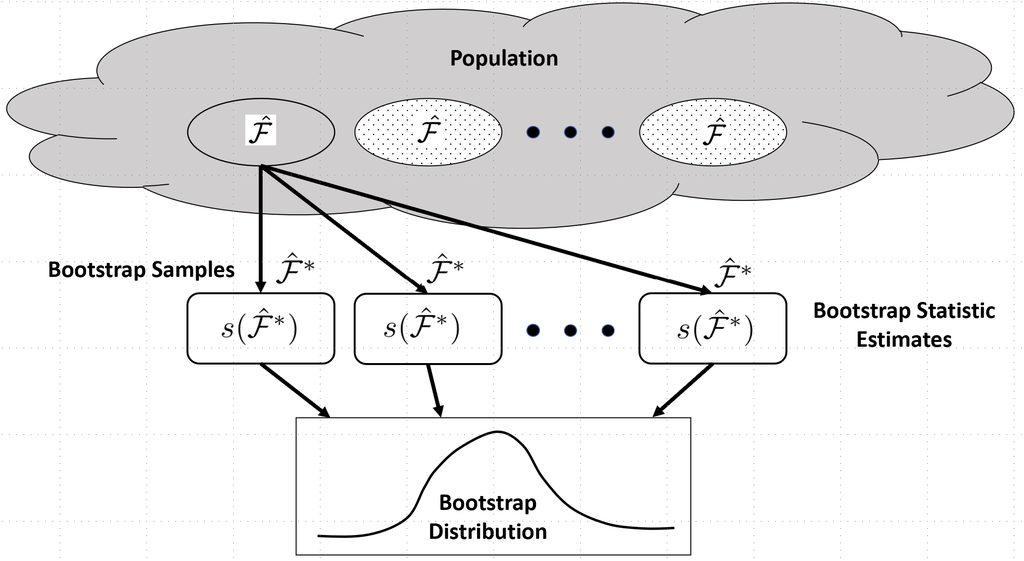

Resampling to estiamte the bootstrap distribution of a statistic

# Bootstrap Distribution

Rather than computing a point estimate directly, bootstrap methods compute a bootstrap distribution of a statistic

- Bootstrap distribution is comprised of values of the statistic computed from bootstrap resamples of the original observations (data sample)
- Computing bootstrap distribution requires **no assumptions about population distribution!**
  - Bootstrap resampling substitutes computer power for paper and pencil statistician power
- Bootstrap resampling estimates the **bootstrap distribution** of a statistic
  - Compute mostly likely point estimate of the statistic, or bootstrap estimate
  - The bootstrap confidence interval is computed from the bootstrap distribution

# Overview of the Bootstrap Algorithm

The bootstrap method follows a simple algorithm. Estimates of the point estimate of a statistic are accumulated by these steps:

1. Randomly sample (e.g. Bernoulli sample) n data with replacement from an original data sample of n values; The re-sample is the same size as the original data sample
2. Re-compute the statistic with each resample
3. Repeat steps 1 and 2 to accumulate the required number of bootstrap samples
4. Accumulated bootstrap values form the bootstrap distribution; An estimate of the sample distribution of the statistic
5. The mean of the computed statistic values is the bootstrap point estimate of the statistic
- By law of large numbers, bootstrap point estimate converges
- Efrom and Tibshirani (1993) and Efron and Hasti (2016) recommend using at least 200 bootstrap samples for point estimates
  - Modern practice is to use 2,000 or more samples

# Overview of the Bootstrap Algorithm

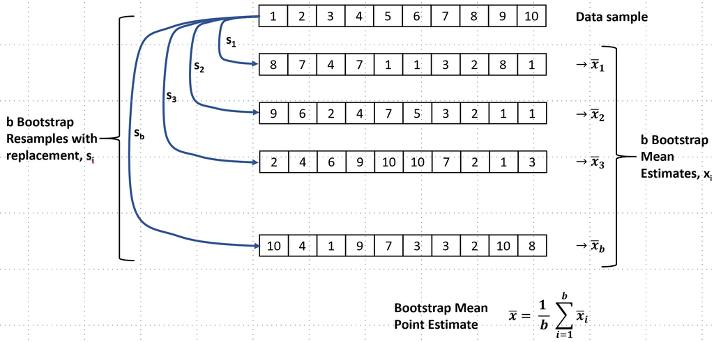

Outline of bootstrap resampling algorithm to compute mean

# Example; One Sample Bootstrap

Use sample of standardized scores of highschool students from [UCLA Statistical Consulting](https://stats.idre.ucla.edu/)

```
##      female  race  ses  schtyp  prog  read  write  math  science  socst
## id
## 70        0     4    1       1     1    57     52    41       47     57
## 121       1     4    2       1     3    68     59    53       63     61
## 86        0     4    3       1     1    44     33    54       58     31
## 141       0     4    3       1     3    63     44    47       53     56
## 172       0     4    2       1     2    47     52    57       53     61
## 113       0     4    2       1     2    44     52    51       63     61
## 50        0     3    2       1     1    50     59    42       53     61
## 11        0     1    2       1     2    34     46    45       39     36
## 84        0     4    2       1     1    63     57    54       58     51
## 48        0     3    2       1     2    57     55    52       50     51
```

# Example; One Sample Bootstrap

Histogram of the math scores

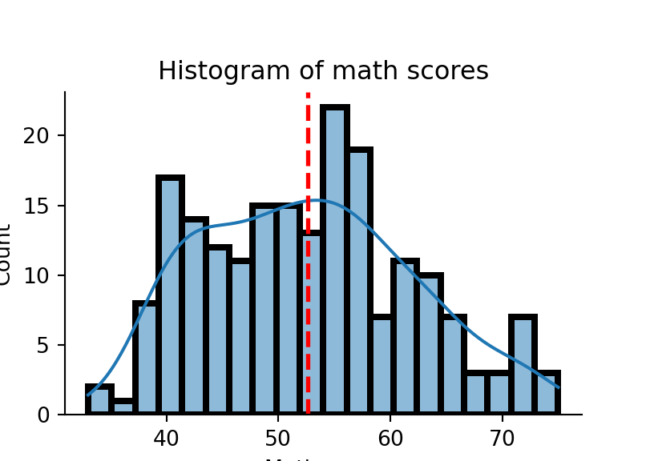

# Example; One Sample Bootstrap

Function to compute single sample bootstrap estimate of statistic

```python
def bootstrap_statistic(x, b, statistic):
    '''
    Function Computes b one-sample bootstrap estimates of data x
    using statistic function.
    '''
    n_samps = len(x)
    boot_vals = []
    for _ in range(b):
        ## The heavy work is done here. The statistic is computed
        ## using the bootstrap sample of the observations
        boot_vals.append(statistic(nr.choice(x, size=n_samps, replace=True)))
    boot_estimate = np.mean(boot_vals)
    print('Bootstrap point estimate = {:6.2f}'.format(boot_estimate))
    return(boot_estimate, boot_vals)

bootstrap_mean_estimate, boot_means = bootstrap_statistic(math, 200, np.mean)
```

```
## Bootstrap point estimate =  52.67
```

# Example; One Sample Bootstrap

Distribution of 200 bootstrap samples of mean estimates

```
## bootstrap point estimate =  52.63
```

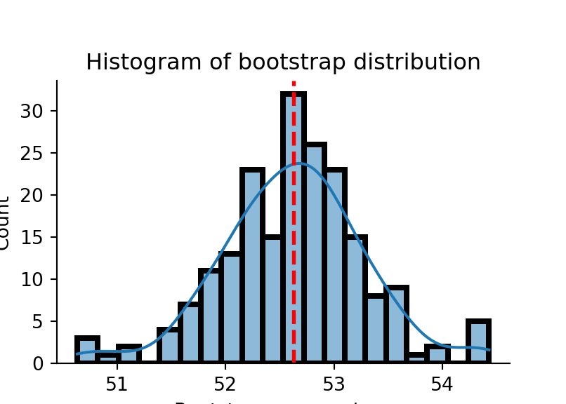

# Bootstrap Confidence Intervals

Distribution of 2000 bootstrap bootstrap confidence intervals?

- Use percentile method:
  1. Define confidence level, eg. 95% or α=0.05
  2. Order b bootstrap samples, $s_i$$, by value
  3. Lower CI index; $i = b∗α/2$
  4. Upper CI index; $i = b∗(1−α/2)$
- Percentile method is know to be biased
  - Bias correction methods available
- Efrom and Tibshirani (1993) and Efron and Hasti (2016) recommend using at least 2,000 bootstrap samples to estimate confidence intervals
  - Modern practice is the use 20,000 or more samples

# Bootstrap Confidence Intervals

Bootstrap confidence intervals are known to be biased!

- Often bootstrap CIs are overly optimistic
- Bias can be significant for asymmetric distributions

# Example; One Sample Bootstrap

Bootstrap distribution of 2000 of mean estimates with confidence intervals

```
## bootstrap point estimate =  52.64
```

```
## At alpha = 0.05, lower and upper bootstrap confidence intervals =  51.33    53.94
```

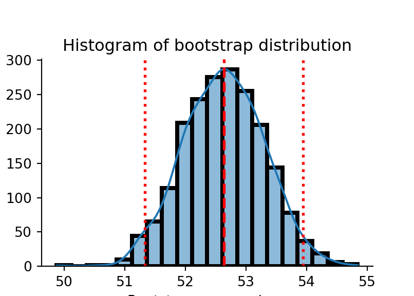